# C:Drive Performance After Enabling the Controller Cache

2015-10-13

## Objective

The objective of this experiment is to identify the impact of enabling the cache on the C: drive controller for the Media Agents and CommServer.

## Result Summary

#### Media Agents

The change of configuration improved the performance of Media Agents mainly on the backup Index phase. The configuration has little impact on the Operating System or CommVault Operations.

#### CommServer

The change of configuration does not bring any improvement and, occasionally, **decreases** the performance of the Operating System ,Microsoft SQL server and CommVault slightly.

## Experiment Description

### Data descriptions

For defining the configuration change impact the following has been collected and analysed.

1. 3 counters were take into account from Microsoft Performance Monitor.
   - **“PhysicalDisk – Disk Transfer/Sec”** –> has an estimator of the IOPS
   - **“PhysicalDisk – Avg Disk Sec/Transfer”** –> has an estimator of the Response Time (or Latency)
   - **“PhysicalDisk – Avg Disk Queue Length”** –> has an estimator of queue associated with IOPS and latency.
2. The counters were collected one week before the change, and one week after.
   - Data Set **“Before”** from 16/09 00:00 to 22/09 23:59;
   - Data set **“Skipped”** from 23/09 00:00 to 23/09 23:59 (Day of the change, NOT considered for the analysis);
   - Data Set **“After”** from 24/09 00:00 to 30/09 23:59.
3. The three counters have a sampling span time of 15 seconds. In other words we have a 4 records for each minute, and its the sampled average of the 15 seconds interval.

### Motivation for the selected counters and modelling used

The main challenge on this analysis is to use the production workload, and NOT a predefined workload (like in a lab controlled environment).

Therefore we need to identify a comparative model and identify its key elements. Since it is known that the Response Time or latency is workload depended, we need to identify the relation between the workload and the performance in the two scenarios (cache on/Off) and establish which is improving the performance.

$Performance=f_{Status\ Cache}(Worload)$

The best and reliable function that links the IOPS with performance is the evergreen **Little Law Theorem**, where

- the length of the Queue can be considerate the “Stress” of the system or the degradation of the performance.
- The response time could be considered an indicator of performance.
- IOPS could be considered an indicator of workload.

$Queue=Response\ Time \bullet IOPS$

note: The formula was used to validate the data $\frac{Queue}{Response\ Time \cdot IOPS}\cong 1$ and it is verified for each record used.

To be more precise in the analysis was included the *Service time* as well, since it is independent from the queue, it provides an additional information for the performance analysis:

$Response\ Time= Service\ Time \cdot (Queue+1)$

## Overview of the Collected Data.

The picture below shows the trend for the 3 counters considered

Line definitions:

1. **Red line –> IOPS**
2. **Green line –> Latency**
3. **Blue Line –> Queue Length**

### Media Agents

The picture below shows the counters trend during 15 days of the experiment. (It is shown the only MA04, but all the Media Agents showed a similar pattern).

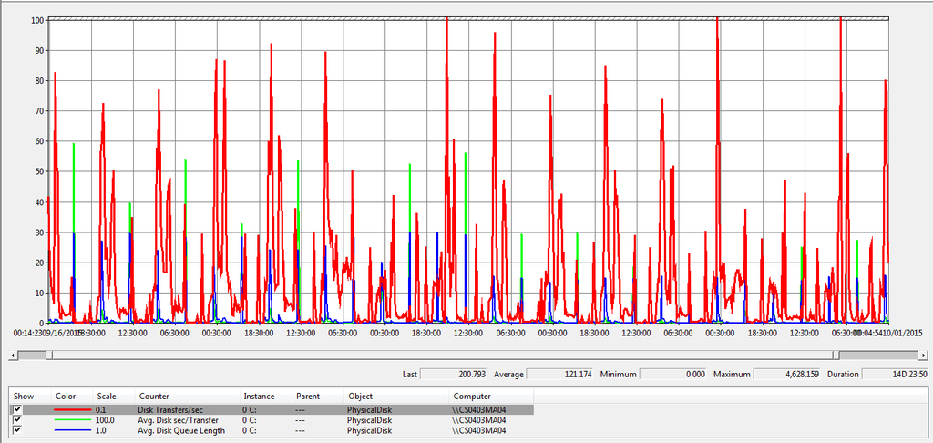

Unfortunately this graph does not allow an easy interpretation. It can barely see that the queue length is generally less intense on the right side (when the cache was enabled) , but unfortunately the IOPS (~ the workload) is not uniform in the two weeks, therefore this graph can have a misleading interpretation.

### CommServer

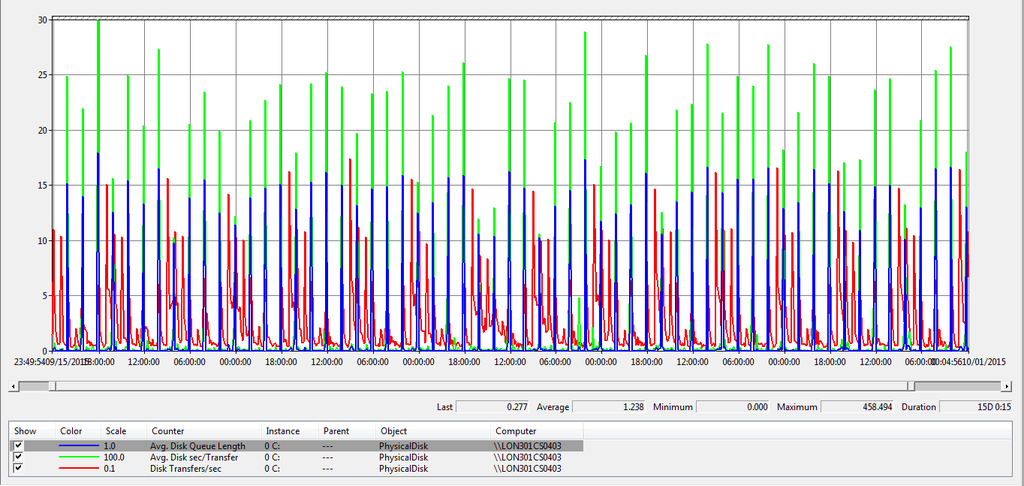

From the graph the difference are not perceptible. The pattern of the two weeks is extremely similar.

## Statistics Overview

For analyzing the impact three different analysis have been carried out.

1. **Distribution Analysis**: the four metrics (IOPS, Response Time, Queue Length, Service Time) are compared before and after the modification.
2. **Variance of the Median by the Hour**: For each hour of day the median of each week is compared for the four metrics.
3. **Time Series Analysis Decomposition**: where the data has been decomposed into the daily cycle, trend and uncorrelated error.

# Media agent

## 1. Distributions

For all the metrics are calculated the relative frequency of the metric value and plotted in a histogram. A log scale was used for a better graphical representation. The following can be noted:

1. It can be seen the **IOPS** (which in the context is the workload), in the two weeks (before and After) is similar but not identical.
   - In particular in the second week, the Workload was less that the first one.
   - This increase the difficulty of the analysis, because we need to identify if the reduced workload is the reason for the change on the performance metric.
2. **The Response Time, Service Time** Even if the two graphs have a similar pattern in the two weeks, they show a shift of the distributions to the left, which represents a performance improvement.

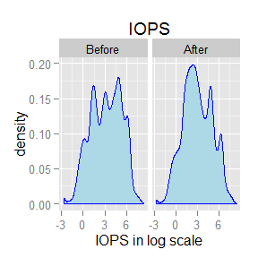

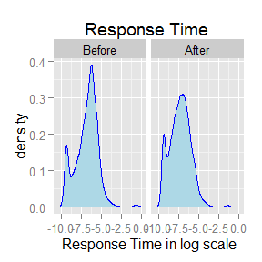

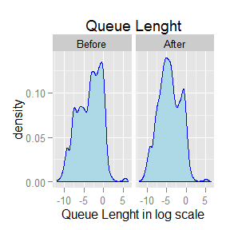

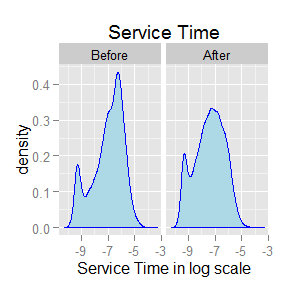

### 2. Variance of the Data by the Hour

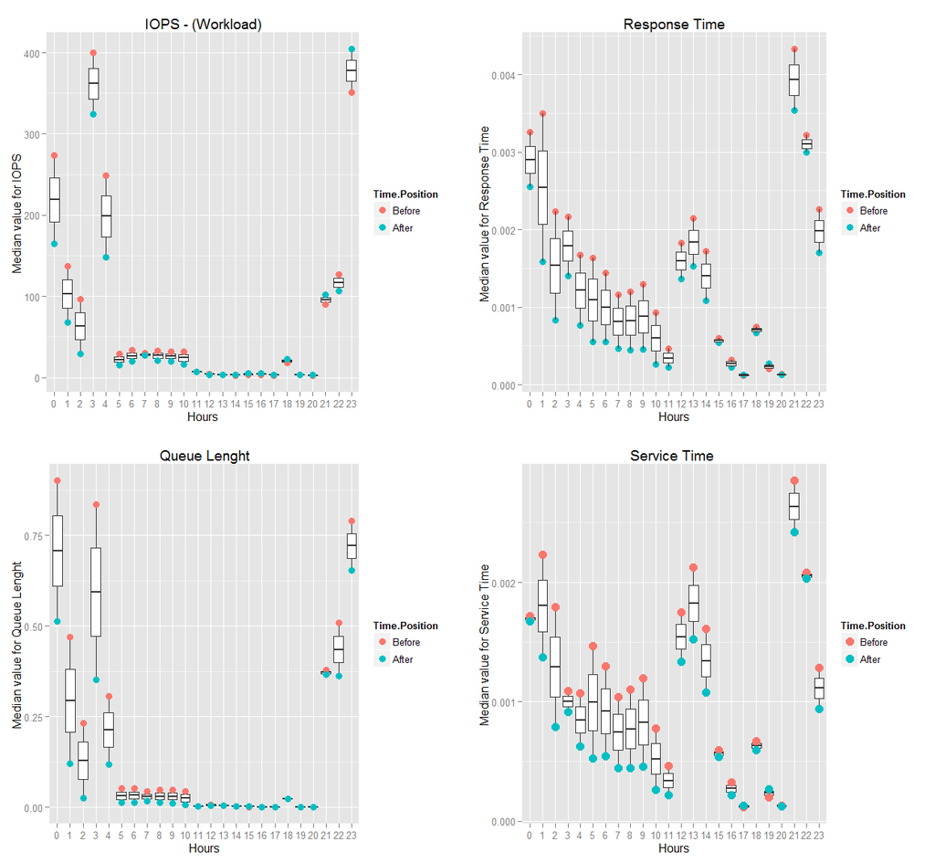

Below the table of the aggregate median of the 4 counters during the 2 weeks of the experiment.

| Time.Position | Median_IOPS | Median_Queue | Median_Response | Median_Service |
| --- | --- | --- | --- | --- |
| Before | 25.3 | 0.041 | 0.00139 | 0.00112 |
| After | 16.9 | 0.012 | 0.00071 | 0.00064 |

## 3. Time Series Analysis

The time series (the value every 15 second of the 4 metrics) have been decomposed into the three temporal component 1. Daily cycle (the variation of the value of the metric due to the daily pattern) 2. The trend 3. The uncorrelated part of the time series(normally called noise).

All the graphs show a performance improvement in the second week. (Except the IOPS that shows a similar trend for the two weeks)

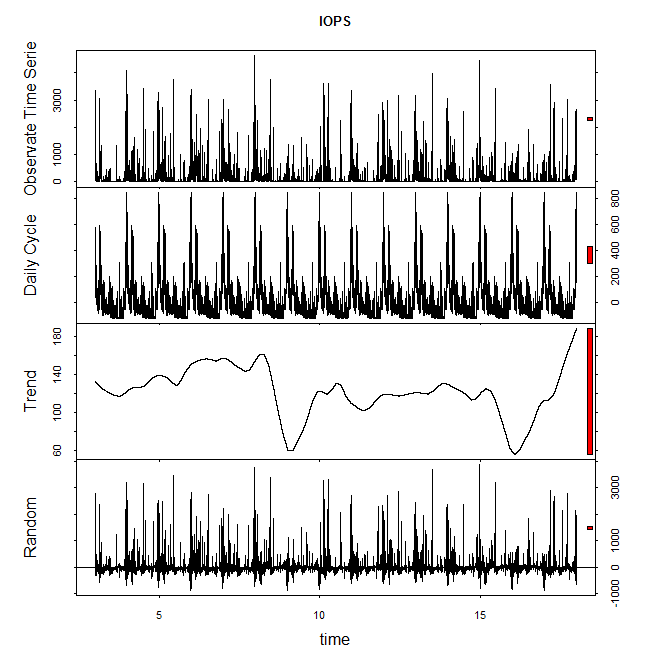

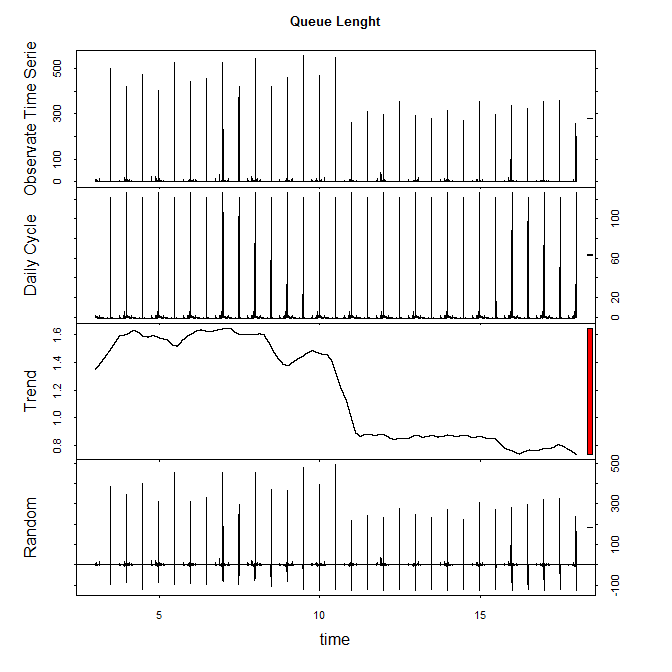

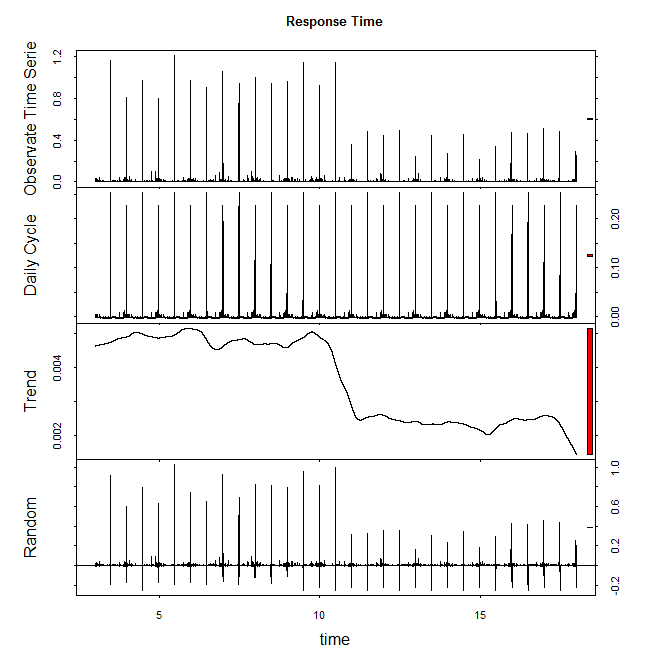

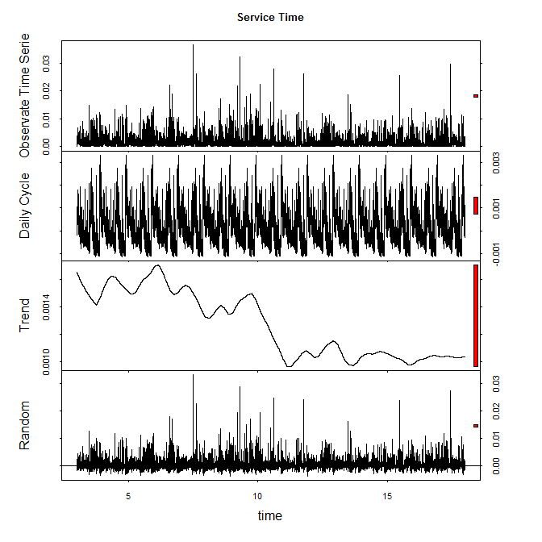

# CommServer

## 1. Distributions

Looking to each distribution of the variable:

1. It can be seen the **IOPS** (which in the context is the workload), in the two weeks (before and After) is practically identical.
2. **The Response Time, Service Time** graphs are extremely similar in the two weeks showing no impact on the second week.

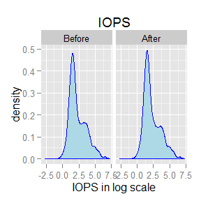

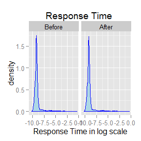

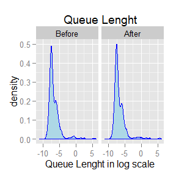

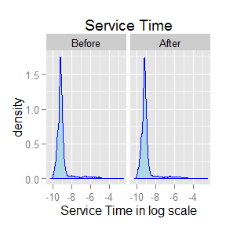

### 2. Variance of the Data by the Hour

The following graphs show the variability for each counter for each hour of the day.

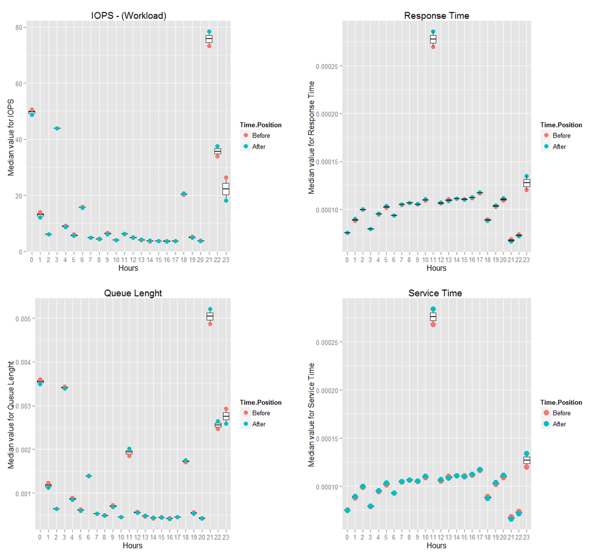

The table below is the aggregate median of the 4 counters during the 2 weeks of the experiment.

| Time.Position | Median_IOPS | Median_Queue | Median_Response | Median_Service |
| --- | --- | --- | --- | --- |
| Before | 6.67 | 0.00075 | 0.0001020 | 0.0001019 |
| After | 6.46 | 0.00072 | 0.0001026 | 0.0001025 |

## 3. Time Series Analysis

The time series (which is the value every 15 second of the 4 metrics) have been decomposed into the 3 temporal component

1. Daily cycle (the variation of the value of the metric due to the daily pattern)
2. The trend
3. The uncorrelated part of the time series( normally called noise).

All the graphs do not show an improvement in the second week…

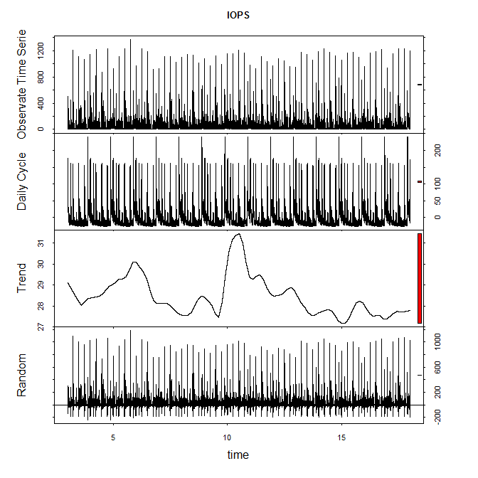

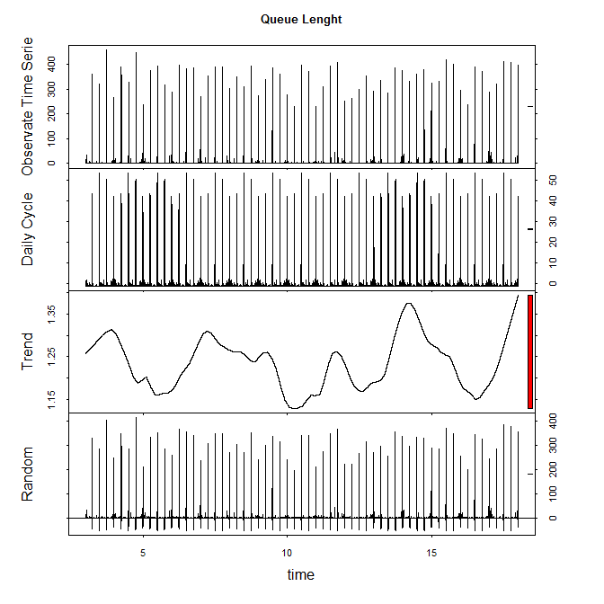

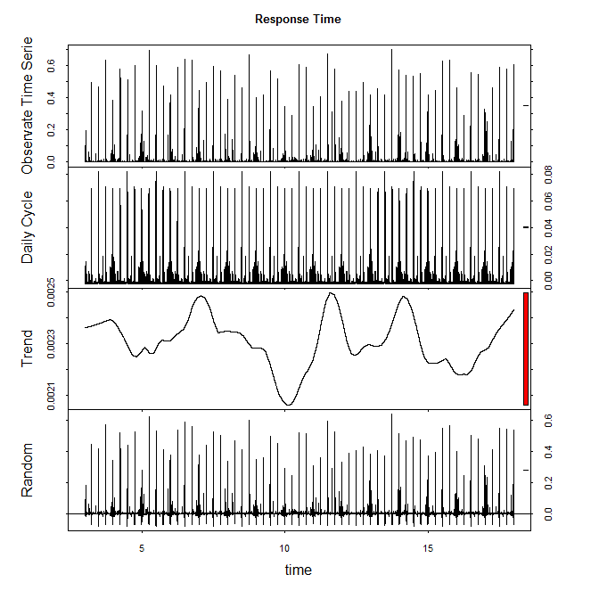

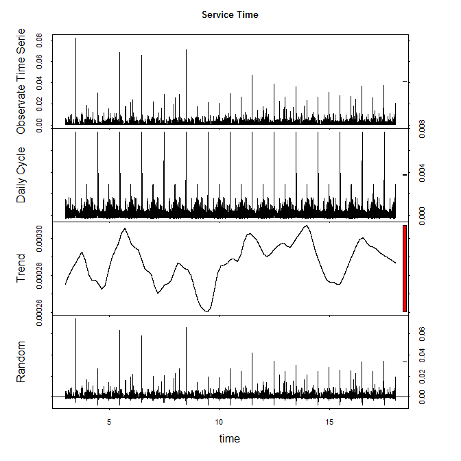